# Morris

Jason Hilton

4 June 2019

The Morris screening method is based on choosing on estimating linear effects of each parameters by varying each parameter One At a Time (OAT) from some starting point. By choosing a large number of starting points and repeating this procedure, you get a more robust estimate of this ‘main effect’. By taking the average absolute effect you can also avoid cancelling. The variance in these effects provides a measure of the non-linear and interaction effects associated with each input.

```r
library(here)
library(tibble)
library(dplyr)
library(tidyr)
```

```r
library(ggplot2)
library(purrr)
library(magrittr)
library(ggrepel)
library(sensitivity)
results_date <- "20190529_134410"
out_df <- readRDS(file.path(here::here(),
                            "results",
                            "summary",
                            results_date,
                            "output_df.rds"))


design <- read.csv(file.path(here::here(),
                            "designs",
                            "morris",
                            paste0("morris_", results_date,".csv")))

varied_pars <- colnames(design)

outputs <- c("Log_ent_count", "mean_cap", "n_arrived")

out_mean_df <- out_df %>% arrange(Point) %>% group_by(Point) %>%
  summarise_at(vars(one_of(outputs)), mean)
```

We can plot both the linear and non-linear effects. Top right of this plot are the most relevant ones. To determine what threshold means we should screen a variable out, we need to (self-)elict what is a meaningful devation from zero and meaningful non-linear effect, and then think about the distribution of these effects to determine a threshold.

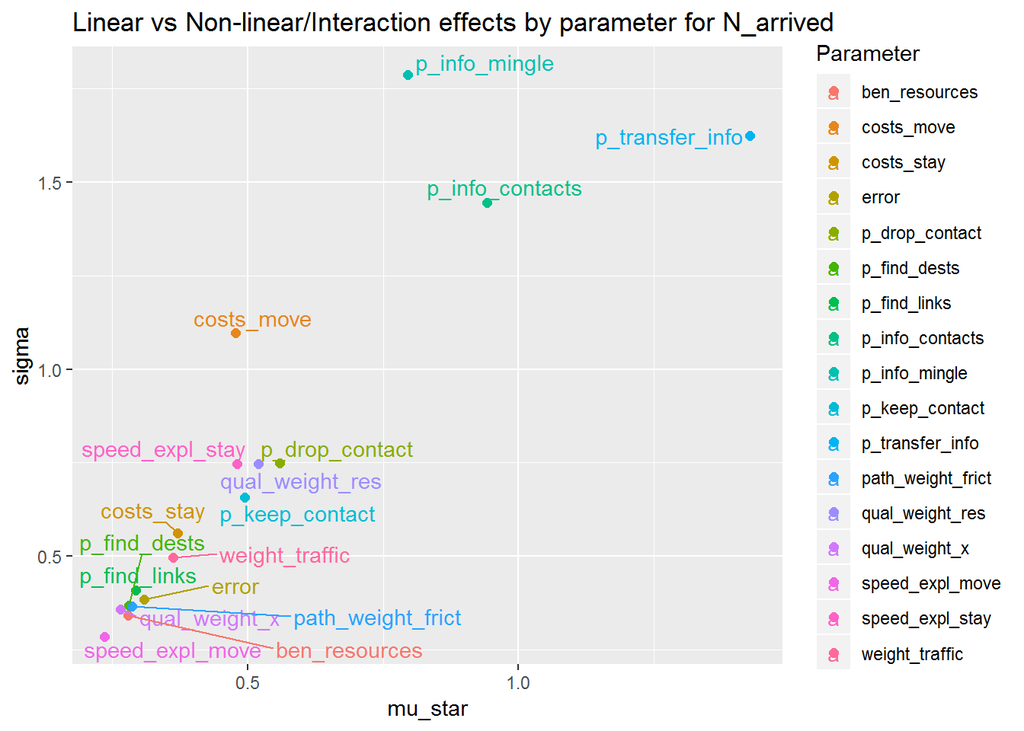

```r
# 20 starting points.

# Annoyingly I didn't save the original morris object I generated the design with
# I regenerate one with the same parameters here to have access to its methods
# I can then overwrite the randomly generated design with the one I produced runs with.
morris_design_obj <- morris(factors=length(varied_pars), r=c(20,100),
            design=list(type="oat",
                        levels=6,
                        grid.jump=2))

design_mat <- as.matrix(design)

rescale <- function(x) (x -min(x))/diff(range(x))

standardise <- function(x) (x- mean(x))/sd(x)

design_mat <- apply(design_mat, 2, rescale)

morris_design_obj$X  <- design_mat

D_arrived <- morris_design_obj # does this deep copy? probably


get_elementary_effects <- function(morris_obj, output){
  tell(morris_obj,output)
  sens_df <- tibble(Parameter=colnames(morris_obj$ee),
                 mu=apply(morris_obj$ee, 2, function(x) mean(x)),
                 mu_star=apply(morris_obj$ee, 2, function(x) mean(abs(x))),
                 sigma=apply(morris_obj$ee, 2, sd))
  return(sens_df)
}






arrived_sens_df <- get_elementary_effects(morris_design_obj,
                                          standardise(out_mean_df$n_arrived))


ggplot(arrived_sens_df,
       aes(x=mu_star, y= sigma, colour=Parameter)) +
  geom_point(size=2) +
  geom_text_repel(aes(mu_star, sigma, label=Parameter)) +
  ggtitle("Linear vs Non-linear/Interaction effects by parameter for N_arrived")
```

Compare with my automatic relevance detection results- some difference of opinion!

```r
ARD <- readRDS(file.path(here(), "results", "ARD_20190530_193859.rds"))


ARD %<>% rename(Parameter=Parameters)

ARD %<>% filter(!grepl("nugget", Model)) %>%
  mutate(Model=ifelse(grepl("^Restricted", Model), "Subset", "All data"))

ARD %<>% filter(Model=="All data") %>%
  mutate(ARD_Selected = (Values < 1.95))

arrived_sens_df <- left_join(arrived_sens_df,
                             ARD %>% filter(Output=="n_arrived"))
```

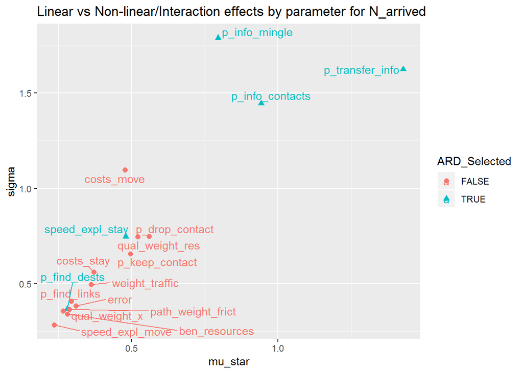

```r
ggplot(arrived_sens_df,
       aes(x=mu_star, y= sigma, colour=ARD_Selected, shape=ARD_Selected)) +
  geom_point(size=2) +
  geom_text_repel(aes(mu_star, sigma, label=Parameter,colour=ARD_Selected)) +
  ggtitle("Linear vs Non-linear/Interaction effects by parameter for N_arrived")
```

# Log-ent

```r
ent_sens_df <- get_elementary_effects(morris_design_obj,
                                      standardise(out_mean_df$Log_ent_count))



ent_sens_df <- left_join(ent_sens_df, ARD %>% filter(Output=="Log_ent_count"))
```

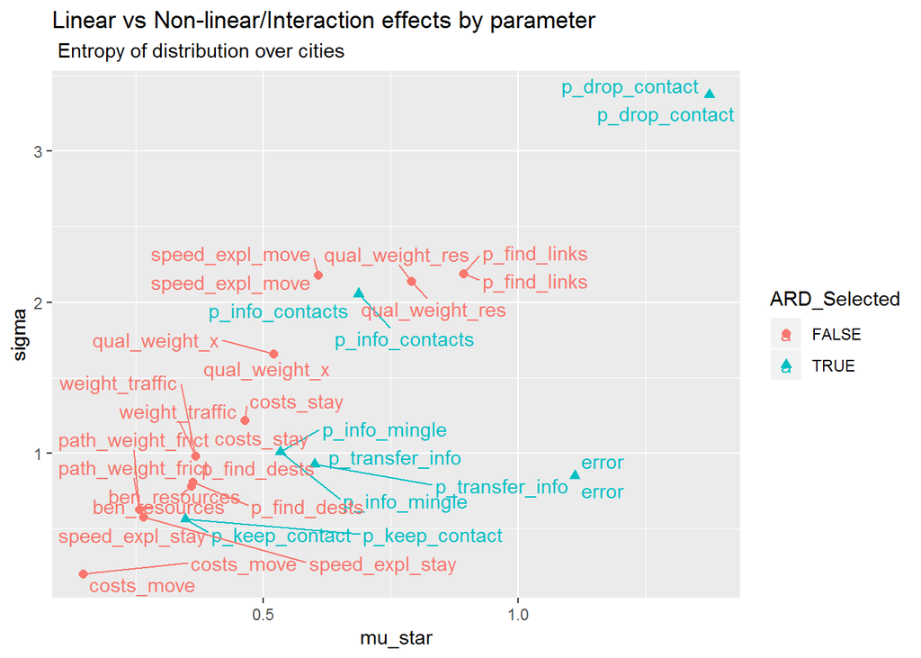

```r
ggplot(ent_sens_df,
       aes(x=mu_star, y= sigma, colour=ARD_Selected, shape=ARD_Selected)) +
  geom_point(size=2) +
  geom_text_repel(aes(mu_star, sigma, label=Parameter,colour=ARD_Selected)) +
  ggtitle("Linear vs Non-linear/Interaction effects by parameter",
          " Entropy of distribution over cities")
```

# mean cap

```r
cap_sens_df <- get_elementary_effects(morris_design_obj,
                                      standardise(out_mean_df$mean_cap))


cap_sens_df <- left_join(cap_sens_df, ARD %>% filter(Output=="mean_cap"))
```

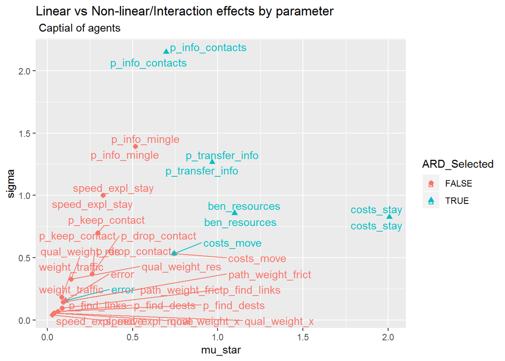

```r
ggplot(cap_sens_df,
       aes(x=mu_star, y= sigma, colour=ARD_Selected, shape=ARD_Selected)) +
  geom_point(size=2) +
  geom_text_repel(aes(mu_star, sigma, label=Parameter,colour=ARD_Selected)) +
  ggtitle("Linear vs Non-linear/Interaction effects by parameter",
          " Captial of agents")
```

# Correlation of city popularity between repetitions

This is probably most unreliable - ie subject to false positives.

```r
log_det <- out_df %>% filter(Repetition==1) %>% select(log_det_exit_cor) %>% unlist

log_det_sens_df <- get_elementary_effects(morris_design_obj,
                                      standardise(log_det))

log_det_sens_df <- left_join(log_det_sens_df, ARD %>% filter(Output=="log_det_exit_cor"))
```

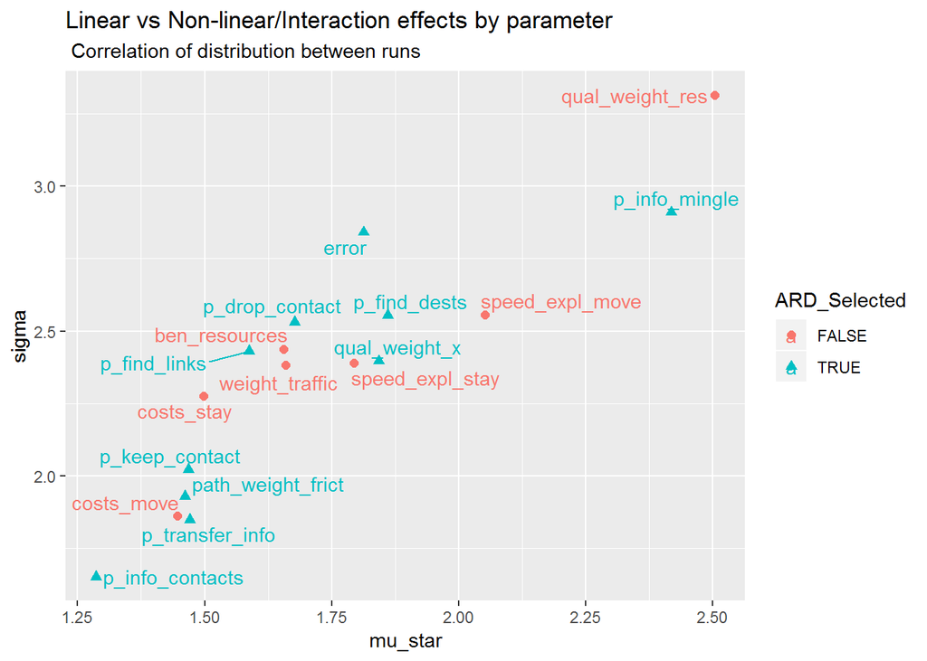

```r
ggplot(log_det_sens_df,
       aes(x=mu_star, y= sigma, colour=ARD_Selected, shape=ARD_Selected)) +
  geom_point(size=2) +
  geom_text_repel(aes(mu_star, sigma, label=Parameter,colour=ARD_Selected)) +
  ggtitle("Linear vs Non-linear/Interaction effects by parameter",
          " Correlation of distribution between runs")
```